# Module 3 - Quiz

Sasha Ajay Malkani

2025-11-22

## Question 1

### 1. A. Load the example SNP data with the following code:

```r
library(snpStats)
library(broom)
ls()
```

```
## character(0)
```

```r
data(for.exercise)
snps.10
```

```
## A SnpMatrix with  1000 rows and  28501 columns
## Row names:  jpt.869 ... ceu.464
## Col names:  rs7909677 ... rs12218790
```

```r
use <- seq(1, ncol(snps.10), 10)
head(use)
```

```
## [1]  1 11 21 31 41 51
```

```r
sub.10 <- snps.10[,use]
sub.10
```

```
## A SnpMatrix with  1000 rows and  2851 columns
## Row names:  jpt.869 ... ceu.464
## Col names:  rs7909677 ... rs12218790
```

```r
snpdata = sub.10@.Data
head(subject.support)
```

```
##         cc stratum
## jpt.869  0 JPT+CHB
## jpt.862  0 JPT+CHB
## jpt.948  0 JPT+CHB
## ceu.564  0     CEU
## ceu.904  0     CEU
## ceu.665  0     CEU
```

```r
status = subject.support$cc
head(status)
```

```
## [1] 0 0 0 0 0 0
```

Fit a linear model and a logistic regression model to the data for the 3rd SNP. What are the coefficients for the SNP variable? How are they interpreted? (Hint: Don’t forget to recode the 0 values to NA for the SNP data)

### 1. B. Recode 0 values to NA

```r
snp3 = as.numeric(snpdata[,3])
snp3[snp3==0] = NA
```

### 1. C. Fit a linear model

```r
lm3 = lm(status ~ snp3)
tidy(lm3)
```

```
## # A tibble: 2 × 5
##   term        estimate std.error statistic  p.value
##   <chr>          <dbl>     <dbl>     <dbl>    <dbl>
## 1 (Intercept)   0.544     0.0549     9.91  3.75e-22
## 2 snp3         -0.0394    0.0468    -0.842 4.00e- 1
```

### 1. D. Fit a logistic regression model

```r
glm3 = glm(status ~ snp3,family="binomial")
tidy(glm3)
```

```
## # A tibble: 2 × 5
##   term        estimate std.error statistic p.value
##   <chr>          <dbl>     <dbl>     <dbl>   <dbl>
## 1 (Intercept)    0.177     0.220     0.806   0.420
## 2 snp3          -0.158     0.188    -0.841   0.400
```

- Linear Model = -0.16

  Logistic Model = -0.04

  Both models are fit on the additive scale. So in the linear model case, the coefficient is the decrease in probability associated with each additional copy of the minor allele. In the logistic regression case, it is the decrease in the log odds ratio associated with each additional copy of the minor allele.
- **Linear Model = -0.04**

  **Logistic Model = -0.16**

  **Both models are fit on the additive scale. So in the linear model case, the** **coefficient is the decrease in probability associated with each additional copy** **of the minor allele. In the logistic regression case, it is the decrease in the** **log odds ratio associated with each additional copy of the minor allele.**
- Linear Model = 0.54

  Logistic Model = 0.18

  Both models are fit on the additive scale. So in the linear model case, the coefficient is the decrease in probability associated with each additional copy of the minor allele. In the logistic regression case, it is the decrease in the log odds ratio associated with each additional copy of the minor allele.
- Linear Model = 0.54

  Logistic Model = 0.18

  Both models are fit on the additive scale. So in both cases the coefficient is the decrease in probability associated with each additional copy of the minor allele.

## Question 2

### In the previous question why might the choice of logistic regression be better than the choice of linear regression?

- The linear model only allows modeling relationships on the additive scale but we might want to consider a dominant or recessive model.
- The log odds is always more interpretable than a change in probability on the additive scale.
- It is customary to use logistic regression for case-control data like those obtained from genome-wide association studies.
- **If you included more variables it would be possible to get negative estimates** **for the probability of being a case from the linear model, but this would be** **prevented with the logistic regression model.**

## Question 3

### 3. A. Load the example SNP data with the following code:

```r
library(snpStats)
library(broom)
ls()
```

```
##  [1] "glm3"            "lm3"             "snp.support"     "snp3"
##  [5] "snpdata"         "snps.10"         "status"          "sub.10"
##  [9] "subject.support" "use"
```

```r
data(for.exercise)
snps.10
```

```
## A SnpMatrix with  1000 rows and  28501 columns
## Row names:  jpt.869 ... ceu.464
## Col names:  rs7909677 ... rs12218790
```

```r
use <- seq(1, ncol(snps.10), 10)
head(use)
```

```
## [1]  1 11 21 31 41 51
```

```r
sub.10 <- snps.10[,use]
sub.10
```

```
## A SnpMatrix with  1000 rows and  2851 columns
## Row names:  jpt.869 ... ceu.464
## Col names:  rs7909677 ... rs12218790
```

```r
snpdata = sub.10@.Data
head(subject.support)
```

```
##         cc stratum
## jpt.869  0 JPT+CHB
## jpt.862  0 JPT+CHB
## jpt.948  0 JPT+CHB
## ceu.564  0     CEU
## ceu.904  0     CEU
## ceu.665  0     CEU
```

```r
status = subject.support$cc
head(status)
```

```
## [1] 0 0 0 0 0 0
```

Fit a logistic regression model on a recessive (need 2 copies of minor allele to confer risk) and additive scale for the 10th SNP. Make a table of the fitted values versus the case/control status. Does one model fit better than the other?

### 3. B. fit a logistic regression model

```r
snp10 = as.numeric(snpdata[,10])
snp10[snp10==0] = NA
glm10 = glm(status ~ snp10, family="binomial")
tidy(glm10)
```

```
## # A tibble: 2 × 5
##   term        estimate std.error statistic p.value
##   <chr>          <dbl>     <dbl>     <dbl>   <dbl>
## 1 (Intercept) -0.00751    0.174    -0.0433   0.965
## 2 snp10        0.00201    0.0933    0.0215   0.983
```

### 3. C. Recessive Model

```r
snp10_dom = (snp10 == 2)
glm10_dom = glm(status ~ snp10_dom, family="binomial")
tidy(glm10_dom)
```

```
## # A tibble: 2 × 5
##   term          estimate std.error statistic p.value
##   <chr>            <dbl>     <dbl>     <dbl>   <dbl>
## 1 (Intercept)    -0.0339    0.0868    -0.391   0.696
## 2 snp10_domTRUE   0.0643    0.127      0.505   0.614
```

### 3. D. Fitted values vs case/control status for logistic regression (additive model)

```r
table(glm10$y, glm10$fitted.values)
```

```
##
##     0.498624476867281 0.499127261301319 0.499630047500341
##   0               202               227                68
##   1               197               234                64
```

### 3. E. Fitted values vs case/control status (Recessive model)

```r
table(glm10_dom$y, glm10_dom$fitted.values)
```

```
##
##     0.491525423728814 0.507592190889371
##   0               270               227
##   1               261               234
```

- The recessive model fits much better since it appears that once you aggregate the heterozygotes and homozygous minor alleles, there is a bigger difference in the proportion of cases and controls.
- The additive model fits much better since there are fewer parameters to fit and the effect size is so large.
- **No, in all cases, the fitted values are near 0.5 and there are about an equal** **number of cases and controls in each group. This is true regardless of whether** **you fit a recessive or additive model.**
- The recessive model shows a strong effect, but the additive model shows no difference so the recessive model is better.

## Question 4

### 4. A. Load the example SNP data with the following code:

```r
library(snpStats)
library(broom)
ls()
```

```
##  [1] "glm10"           "glm10_dom"       "glm3"            "lm3"
##  [5] "snp.support"     "snp10"           "snp10_dom"       "snp3"
##  [9] "snpdata"         "snps.10"         "status"          "sub.10"
## [13] "subject.support" "use"
```

```r
data(for.exercise)
snps.10
```

```
## A SnpMatrix with  1000 rows and  28501 columns
## Row names:  jpt.869 ... ceu.464
## Col names:  rs7909677 ... rs12218790
```

```r
use <- seq(1, ncol(snps.10), 10)
head(use)
```

```
## [1]  1 11 21 31 41 51
```

```r
sub.10 <- snps.10[,use]
sub.10
```

```
## A SnpMatrix with  1000 rows and  2851 columns
## Row names:  jpt.869 ... ceu.464
## Col names:  rs7909677 ... rs12218790
```

```r
snpdata = sub.10@.Data
head(subject.support)
```

```
##         cc stratum
## jpt.869  0 JPT+CHB
## jpt.862  0 JPT+CHB
## jpt.948  0 JPT+CHB
## ceu.564  0     CEU
## ceu.904  0     CEU
## ceu.665  0     CEU
```

```r
status = subject.support$cc
head(status)
```

```
## [1] 0 0 0 0 0 0
```

Fit an additive logistic regression model to each SNP. What is the average effect size? What is the max? What is the minimum?

### 4. B. Fit an additive logistic regression model to each SNP

```r
results = rep(NA, dim(snpdata)[2])
for (i in 1:ncol(snpdata)){
  snpdata_i = as.numeric(snpdata[,i])
  snpdata_i[snpdata_i == 0] = NA
  glm_i = glm(status ~ snpdata_i, family = "binomial")
  results[i] = tidy(glm_i)$statistic[2]
}
```

### 4. C. Average effect size

```r
mean(results)
```

```
## [1] 0.007155377
```

### 4. D. Minimum effect size

```r
min(results)
```

```
## [1] -4.251469
```

### 4. E. maximum effect size

```r
max(results)
```

```
## [1] 3.900891
```

- Average effect size = 0.02, minimum = -0.88, maximum = 0.88
- **Average effect size = 0.007, minimum = -4.25, maximum = 3.90**
- Average effect size = -0.02, minimum =-3.59 , maximum = 4.16
- Average effect size = 1.35, minimum =-6.26 , maximum = 6.26

## Question 5

### 5. A. Load the example SNP data with the following code:

```r
library(snpStats)
library(broom)
ls()
```

```
##  [1] "glm_i"           "glm10"           "glm10_dom"       "glm3"
##  [5] "i"               "lm3"             "results"         "snp.support"
##  [9] "snp10"           "snp10_dom"       "snp3"            "snpdata"
## [13] "snpdata_i"       "snps.10"         "status"          "sub.10"
## [17] "subject.support" "use"
```

```r
data(for.exercise)
snps.10
```

```
## A SnpMatrix with  1000 rows and  28501 columns
## Row names:  jpt.869 ... ceu.464
## Col names:  rs7909677 ... rs12218790
```

```r
use <- seq(1, ncol(snps.10), 10)
head(use)
```

```
## [1]  1 11 21 31 41 51
```

```r
sub.10 <- snps.10[,use]
sub.10
```

```
## A SnpMatrix with  1000 rows and  2851 columns
## Row names:  jpt.869 ... ceu.464
## Col names:  rs7909677 ... rs12218790
```

```r
snpdata = sub.10@.Data
head(subject.support)
```

```
##         cc stratum
## jpt.869  0 JPT+CHB
## jpt.862  0 JPT+CHB
## jpt.948  0 JPT+CHB
## ceu.564  0     CEU
## ceu.904  0     CEU
## ceu.665  0     CEU
```

```r
status = subject.support$cc
head(status)
```

```
## [1] 0 0 0 0 0 0
```

Fit an additive logistic regression model to each SNP and square the coefficients. What is the correlation with the results from using snp.rhs.tests and chi.squared? Why does this make sense?

### 5. B. Square the coefficients

```r
results_coeff_squre =  results^2
```

### 5. C. Correlation with the results from using snp.rhs.tests and chi.squared

```r
glm_all = snp.rhs.tests(status ~ 1, snp.data = sub.10)
cor(results_coeff_squre, chi.squared(glm_all))
```

```
## [1] 0.9992946
```

- 0.99 They are both testing for the same association using the same additive regression model on the logistic scale. But it doesn’t make sense since they should be perfectly correlated.
- 0.99 **They are both testing for the same association using the same additive** **regression model on the logistic scale but using slightly different tests.**
- 0.002 It doesn’t make sense since they are both testing for the same association using the same additive regression model on the logistic scale. But it doesn’t make sense since they should be perfectly correlated.
- 0.81 They are both testing for the same association using the same additive regression model on the logistic scale. But it doesn’t make sense since they should be perfectly correlated.

## Question 6

### 6. A. Load the Montgomery and Pickrell eSet:

```r
library(devtools)
library(Biobase)
con =url("http://bowtie-bio.sourceforge.net/recount/ExpressionSets/montpick_eset.RData")
load(file=con)
close(con)
ls()
```

```
##  [1] "con"                 "glm_all"             "glm_i"
##  [4] "glm10"               "glm10_dom"           "glm3"
##  [7] "i"                   "lm3"                 "montpick.eset"
## [10] "results"             "results_coeff_squre" "snp.support"
## [13] "snp10"               "snp10_dom"           "snp3"
## [16] "snpdata"             "snpdata_i"           "snps.10"
## [19] "status"              "sub.10"              "subject.support"
## [22] "use"
```

```r
mp = montpick.eset
mp
```

```
## ExpressionSet (storageMode: lockedEnvironment)
## assayData: 52580 features, 129 samples
##   element names: exprs
## protocolData: none
## phenoData
##   sampleNames: NA06985 NA06986 ... NA19257 (129 total)
##   varLabels: sample.id num.tech.reps population study
##   varMetadata: labelDescription
## featureData
##   featureNames: ENSG00000000003 ENSG00000000005 ... LRG_99 (52580
##     total)
##   fvarLabels: gene
##   fvarMetadata: labelDescription
## experimentData: use 'experimentData(object)'
## Annotation:
```

```r
pdata=pData(mp)
head(pdata)
```

```
##         sample.id num.tech.reps population      study
## NA06985   NA06985             1        CEU Montgomery
## NA06986   NA06986             1        CEU Montgomery
## NA06994   NA06994             1        CEU Montgomery
## NA07000   NA07000             1        CEU Montgomery
## NA07037   NA07037             1        CEU Montgomery
## NA07051   NA07051             1        CEU Montgomery
```

```r
edata=as.data.frame(exprs(mp))
head(edata, n = 1)
```

```
##                 NA06985 NA06986 NA06994 NA07000 NA07037 NA07051 NA07346 NA07347
## ENSG00000000003       0       0       0       1       0       0       0       0
##                 NA07357 NA10847 NA10851 NA11829 NA11830 NA11831 NA11832 NA11840
## ENSG00000000003       0       0       0       0       0       0       0       0
##                 NA11881 NA11894 NA11918 NA11920 NA11931 NA11992 NA11993 NA11994
## ENSG00000000003       0       0       0       0       1       0       0       0
##                 NA11995 NA12003 NA12004 NA12005 NA12006 NA12043 NA12044 NA12045
## ENSG00000000003       0       0       0       0       0       0       0       1
##                 NA12144 NA12154 NA12155 NA12156 NA12234 NA12249 NA12287 NA12414
## ENSG00000000003       0       0       0       0       0       0       0       1
##                 NA12489 NA12716 NA12717 NA12750 NA12751 NA12760 NA12761 NA12762
## ENSG00000000003       0       0       0       0       0       0       0       0
##                 NA12763 NA12776 NA12812 NA12813 NA12814 NA12815 NA12828 NA12872
## ENSG00000000003       0       1       0       0       0       0       0       0
##                 NA12873 NA12874 NA12891 NA12892 NA18486 NA18498 NA18499 NA18501
## ENSG00000000003       0       0       0       0       0       0       0       0
##                 NA18502 NA18504 NA18505 NA18507 NA18508 NA18510 NA18511 NA18516
## ENSG00000000003       0       0       5       0       0       0       0       0
##                 NA18517 NA18519 NA18520 NA18522 NA18523 NA18852 NA18853 NA18855
## ENSG00000000003       0       0       0       0       0       0       0       0
##                 NA18856 NA18858 NA18861 NA18862 NA18870 NA18871 NA18909 NA18912
## ENSG00000000003       0       1       0       0       0       0       0       0
##                 NA18913 NA18916 NA19093 NA19098 NA19099 NA19101 NA19102 NA19108
## ENSG00000000003       0       0       0       0       0       0       0       0
##                 NA19114 NA19116 NA19119 NA19127 NA19128 NA19130 NA19131 NA19137
## ENSG00000000003       0       0       0       0       0       0       0       0
##                 NA19138 NA19140 NA19143 NA19144 NA19147 NA19152 NA19153 NA19159
## ENSG00000000003       1       0       0       0       0       0       0       0
##                 NA19160 NA19171 NA19172 NA19190 NA19192 NA19193 NA19200 NA19201
## ENSG00000000003       0       0       0       0       0       0       0       2
##                 NA19203 NA19204 NA19209 NA19210 NA19222 NA19225 NA19238 NA19239
## ENSG00000000003       0       0       0       0       0       0       0       0
##                 NA19257
## ENSG00000000003       0
```

```r
fdata = fData(mp)
head(fdata)
```

```
##                            gene
## ENSG00000000003 ENSG00000000003
## ENSG00000000005 ENSG00000000005
## ENSG00000000419 ENSG00000000419
## ENSG00000000457 ENSG00000000457
## ENSG00000000460 ENSG00000000460
## ENSG00000000938 ENSG00000000938
```

Do the log2(data + 1) transform and fit calculate F-statistics for the difference between studies/populations using genefilter:rowFtests and using genefilter:rowttests. Do you get the same statistic? Do you get the same p-value?

### 6. B. Log2 transform

```r
edata = log2(as.matrix(edata) + 1)
```

### 6. C. Perform rowttests

```r
library(genefilter)
tstats_obj = rowttests(edata, as.factor(pdata$population))
tidyr::tibble(tstats_obj)
```

```
## # A tibble: 52,580 × 3
##    statistic       dm    p.value
##        <dbl>    <dbl>      <dbl>
##  1   -0.0996 -0.00609   9.21e- 1
##  2    0.0989  0.00217   9.21e- 1
##  3   -9.36   -1.38      3.77e-16
##  4   -8.63   -1.19      2.14e-14
##  5   -5.92   -1.05      2.77e- 8
##  6   -6.68   -1.29      6.79e-10
##  7  NaN       0       NaN
##  8   -6.02   -0.807     1.73e- 8
##  9  NaN       0       NaN
## 10   -6.88   -0.786     2.38e-10
## # ℹ 52,570 more rows
```

### 6. D. Perform rowFtests

```r
fstats_obj = rowFtests(edata, as.factor(pdata$population))
tidyr::tibble(fstats_obj)
```

```
## # A tibble: 52,580 × 2
##    statistic    p.value
##        <dbl>      <dbl>
##  1   0.00991   9.21e- 1
##  2   0.00978   9.21e- 1
##  3  87.6       3.77e-16
##  4  74.5       2.14e-14
##  5  35.1       2.77e- 8
##  6  44.6       6.79e-10
##  7 NaN       NaN
##  8  36.3       1.73e- 8
##  9 NaN       NaN
## 10  47.4       2.38e-10
## # ℹ 52,570 more rows
```

### 6. E. Histogram plots of T-tests and F-Tests

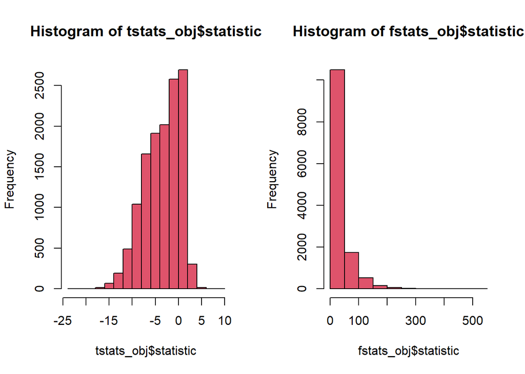

```r
par(mfrow=c(1,2))
hist(tstats_obj$statistic, col=2)
hist(fstats_obj$statistic, col=2)
```

- You get the same p-values and statistics. This is because the F-statistic and t-statistic are the exact same in this case.
- You get different p-values and statistics. The F-statistic and t-statistic are testing the same thing but do it totally differently.
- **You get the same p-value but different statistics. This is because the F-statistic** **and t-statistic test the same thing when doing a two group test and one is a** **transform of the other.**
- You get different p-values but the same statistic. This is because the F-statistic and t-statistic test the same thing when doing a two group test and one is a transform of the other.

## Question 7

### 7. A. Load the Montgomery and Pickrell eSet:

```r
library(devtools)
library(Biobase)
con =url("http://bowtie-bio.sourceforge.net/recount/ExpressionSets/montpick_eset.RData")
load(file=con)
close(con)
ls()
```

```
##  [1] "con"                 "edata"               "fdata"
##  [4] "fstats_obj"          "glm_all"             "glm_i"
##  [7] "glm10"               "glm10_dom"           "glm3"
## [10] "i"                   "lm3"                 "montpick.eset"
## [13] "mp"                  "pdata"               "results"
## [16] "results_coeff_squre" "snp.support"         "snp10"
## [19] "snp10_dom"           "snp3"                "snpdata"
## [22] "snpdata_i"           "snps.10"             "status"
## [25] "sub.10"              "subject.support"     "tstats_obj"
## [28] "use"
```

```r
mp = montpick.eset
mp
```

```
## ExpressionSet (storageMode: lockedEnvironment)
## assayData: 52580 features, 129 samples
##   element names: exprs
## protocolData: none
## phenoData
##   sampleNames: NA06985 NA06986 ... NA19257 (129 total)
##   varLabels: sample.id num.tech.reps population study
##   varMetadata: labelDescription
## featureData
##   featureNames: ENSG00000000003 ENSG00000000005 ... LRG_99 (52580
##     total)
##   fvarLabels: gene
##   fvarMetadata: labelDescription
## experimentData: use 'experimentData(object)'
## Annotation:
```

```r
pdata=pData(mp)
head(pdata)
```

```
##         sample.id num.tech.reps population      study
## NA06985   NA06985             1        CEU Montgomery
## NA06986   NA06986             1        CEU Montgomery
## NA06994   NA06994             1        CEU Montgomery
## NA07000   NA07000             1        CEU Montgomery
## NA07037   NA07037             1        CEU Montgomery
## NA07051   NA07051             1        CEU Montgomery
```

```r
edata=as.data.frame(exprs(mp))
head(edata, n = 1)
```

```
##                 NA06985 NA06986 NA06994 NA07000 NA07037 NA07051 NA07346 NA07347
## ENSG00000000003       0       0       0       1       0       0       0       0
##                 NA07357 NA10847 NA10851 NA11829 NA11830 NA11831 NA11832 NA11840
## ENSG00000000003       0       0       0       0       0       0       0       0
##                 NA11881 NA11894 NA11918 NA11920 NA11931 NA11992 NA11993 NA11994
## ENSG00000000003       0       0       0       0       1       0       0       0
##                 NA11995 NA12003 NA12004 NA12005 NA12006 NA12043 NA12044 NA12045
## ENSG00000000003       0       0       0       0       0       0       0       1
##                 NA12144 NA12154 NA12155 NA12156 NA12234 NA12249 NA12287 NA12414
## ENSG00000000003       0       0       0       0       0       0       0       1
##                 NA12489 NA12716 NA12717 NA12750 NA12751 NA12760 NA12761 NA12762
## ENSG00000000003       0       0       0       0       0       0       0       0
##                 NA12763 NA12776 NA12812 NA12813 NA12814 NA12815 NA12828 NA12872
## ENSG00000000003       0       1       0       0       0       0       0       0
##                 NA12873 NA12874 NA12891 NA12892 NA18486 NA18498 NA18499 NA18501
## ENSG00000000003       0       0       0       0       0       0       0       0
##                 NA18502 NA18504 NA18505 NA18507 NA18508 NA18510 NA18511 NA18516
## ENSG00000000003       0       0       5       0       0       0       0       0
##                 NA18517 NA18519 NA18520 NA18522 NA18523 NA18852 NA18853 NA18855
## ENSG00000000003       0       0       0       0       0       0       0       0
##                 NA18856 NA18858 NA18861 NA18862 NA18870 NA18871 NA18909 NA18912
## ENSG00000000003       0       1       0       0       0       0       0       0
##                 NA18913 NA18916 NA19093 NA19098 NA19099 NA19101 NA19102 NA19108
## ENSG00000000003       0       0       0       0       0       0       0       0
##                 NA19114 NA19116 NA19119 NA19127 NA19128 NA19130 NA19131 NA19137
## ENSG00000000003       0       0       0       0       0       0       0       0
##                 NA19138 NA19140 NA19143 NA19144 NA19147 NA19152 NA19153 NA19159
## ENSG00000000003       1       0       0       0       0       0       0       0
##                 NA19160 NA19171 NA19172 NA19190 NA19192 NA19193 NA19200 NA19201
## ENSG00000000003       0       0       0       0       0       0       0       2
##                 NA19203 NA19204 NA19209 NA19210 NA19222 NA19225 NA19238 NA19239
## ENSG00000000003       0       0       0       0       0       0       0       0
##                 NA19257
## ENSG00000000003       0
```

```r
fdata = fData(mp)
head(fdata)
```

```
##                            gene
## ENSG00000000003 ENSG00000000003
## ENSG00000000005 ENSG00000000005
## ENSG00000000419 ENSG00000000419
## ENSG00000000457 ENSG00000000457
## ENSG00000000460 ENSG00000000460
## ENSG00000000938 ENSG00000000938
```

First test for differences between the studies using the DESeq2 package using the DESeq function. Then do the log2(data + 1) transform and do the test for differences between studies using the limma package and the lmFit, ebayes and topTable functions. What is the correlation in the statistics between the two analyses? Are there more differences for the large statistics or the small statistics (hint: Make an MA-plot).

### 7. B.Load Libraries

```r
library(DESeq2)
library(limma)
library(edge)
library(genefilter)
```

### 7. C. Using DESeq2 test the differences between the studies

```r
de = DESeqDataSetFromMatrix(edata, pdata, ~study)
glm_de = DESeq(de)
```

```
## -- replacing outliers and refitting for 231 genes
## -- DESeq argument 'minReplicatesForReplace' = 7
## -- original counts are preserved in counts(dds)
```

```r
result_de = results(glm_de)
result_de
```

```
## log2 fold change (MLE): study Pickrell vs Montgomery
## Wald test p-value: study Pickrell vs Montgomery
## DataFrame with 52580 rows and 6 columns
##                   baseMean log2FoldChange     lfcSE      stat      pvalue
##                  <numeric>      <numeric> <numeric> <numeric>   <numeric>
## ENSG00000000003  0.0901579      -0.622016 1.5358963 -0.404986 6.85488e-01
## ENSG00000000005  0.0180501      -0.764197 2.9147420 -0.262183 7.93180e-01
## ENSG00000000419 41.7846277       0.557647 0.0984858  5.662203 1.49442e-08
## ENSG00000000457 48.6919241       0.421344 0.0906146  4.649845 3.32185e-06
## ENSG00000000460  9.6110455       0.196627 0.1386978  1.417668 1.56288e-01
## ...                    ...            ...       ...       ...         ...
## LRG_94                   0             NA        NA        NA          NA
## LRG_96                   0             NA        NA        NA          NA
## LRG_97                   0             NA        NA        NA          NA
## LRG_98                   0             NA        NA        NA          NA
## LRG_99                   0             NA        NA        NA          NA
##                        padj
##                   <numeric>
## ENSG00000000003          NA
## ENSG00000000005          NA
## ENSG00000000419 1.03454e-07
## ENSG00000000457 1.56256e-05
## ENSG00000000460 2.37764e-01
## ...                     ...
## LRG_94                   NA
## LRG_96                   NA
## LRG_97                   NA
## LRG_98                   NA
## LRG_99                   NA
```

### 7. D. Using limma test the differences

```r
edata = log2(as.matrix(edata) + 1)
mod = model.matrix(~ as.factor(pdata$study))
fit_limma = lmFit(edata, mod)
ebayes_limma = eBayes(fit_limma)
top = topTable(ebayes_limma,number=dim(edata)[1], sort.by="none")
```

```
## Removing intercept from test coefficients
```

```r
head(top)
```

```
##                        logFC    AveExpr           t      P.Value    adj.P.Val
## ENSG00000000003  0.006085870 0.08658857  0.09974912 9.207002e-01 1.000000e+00
## ENSG00000000005 -0.002173913 0.01550388 -0.09908607 9.212256e-01 1.000000e+00
## ENSG00000000419  1.383393777 5.29924839  9.37449669 3.340535e-16 1.718643e-14
## ENSG00000000457  1.187857225 5.55601338  8.64599720 1.929181e-14 7.219667e-13
## ENSG00000000460  1.050118063 3.23182448  5.93370242 2.620826e-08 3.907765e-07
## ENSG00000000938  1.288773101 4.67655249  6.69028454 6.337108e-10 1.181579e-08
##                          B
## ENSG00000000003 -10.081102
## ENSG00000000005 -10.081169
## ENSG00000000419  23.596157
## ENSG00000000457  19.556268
## ENSG00000000460   5.580042
## ENSG00000000938   9.244591
```

### 7. E. Correlation in the statistics between two analyses

```r
cor(result_de$stat, top$t)
```

```
## [1] NA
```

### 7. F. Make an MA-plot

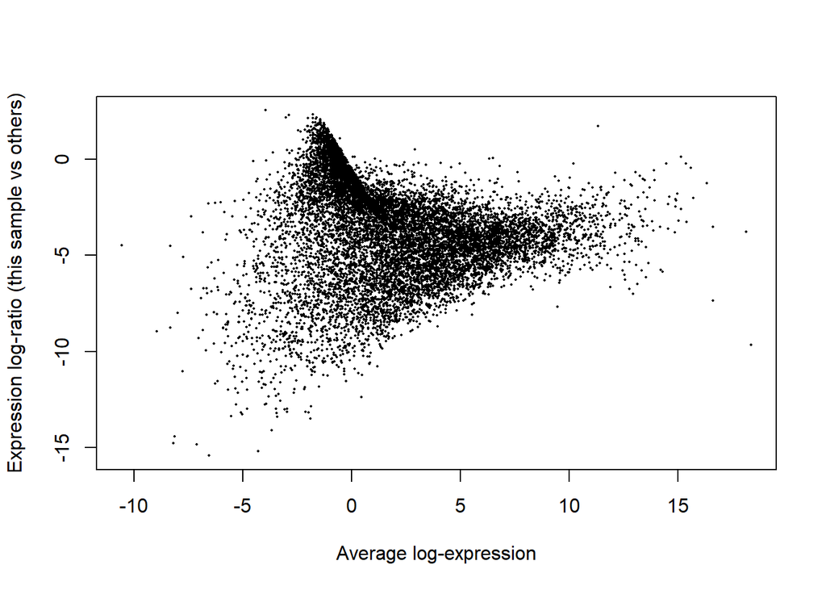

```r
y = cbind(result_de$stat, top$t)
limma::plotMA(y)
```

## Question 8

### 8. A. DESeq analysis

```r
fp_bh = p.adjust(result_de$pvalue, method="BH")
sum(fp_bh < 0.05)
```

```
## [1] NA
```

### 8. B. limma analysis

```r
fp_bh = p.adjust(top$P.Value, method="BH")
sum(fp_bh < 0.05)
```

```
## [1] 6622
```

  limma = 0 significant
- DESeq = 1119 significant;

  limma = 2328 significant

## Question 9

Is the number of significant differences surprising for the analysis comparing studies from Question 8? Why or why not?

- Yes. This is a very large number of genes different between studies and we don’t have a good explanation.
- **Yes and no. It is surprising because there is a large fraction of the genes** **that are significantly different, but it isn’t that surprising because we would** **expect that when comparing measurements from very different batches.**
- No. We are testing many genes so we expect a huge fraction to be different between studies.
- No. There are very few genes different between studies and that is what we would expect.

## Question 10

```r
Sys.Date()
```

```
## [1] "2025-11-26"
```